# Dados de commits no github

Vinicius Brandão Araújo

```r
library(here)
library(tidyverse)
library(lubridate)
library(timeDate)
library(resample)

theme_set(theme_bw())
```

```r
readr::read_csv(here::here("data/github-users-committing-filetypes.csv"),
                      progress = FALSE,
                      col_types = cols(
                        file_extension = col_character(),
                        month_day = col_integer(),
                        the_month = col_integer(),
                        the_year = col_integer(),
                        users = col_integer()
                        )) -> data
data %>%
  glimpse()
```

```
## Observations: 13,802
## Variables: 5
## $ file_extension <chr> "md", "md", "md", "md", "md", "md", "md", "md",...
## $ month_day      <int> 18, 17, 27, 16, 26, 21, 4, 22, 23, 1, 12, 3, 2,...
## $ the_month      <int> 2, 2, 1, 2, 1, 3, 2, 2, 2, 2, 4, 2, 2, 2, 4, 3,...
## $ the_year       <int> 2016, 2016, 2016, 2016, 2016, 2017, 2016, 2016,...
## $ users          <int> 10279, 10208, 10118, 10045, 10020, 10015, 9991,...
```

## Objetivo da analise.

Esta análise, realizada no contexto da disciplina Ciência de Dados 1, tem por objetivo avaliar a popularidade de linguagens de programação no período entre 2016 e 2017 segundo dados registrados no GitHub. Essa análise serve de mote para trabalharmos conceitos de inferência, intervalos de confiança, significância, entre outros.

## Sobre os dados

Usaremos uma amostra de dados que contém informações sobre quantos usuários fizeram atividade no GitHub usando uma determinada linguagem de programação. Em especial escolhemos as Linguagens Go e Python. Para está analise iremos verificar se a data é no final de semana ou não para facilitar a observação.

```r
data %>%
  mutate(cronology = lubridate::ymd(paste(the_year,
                         the_month,
                         month_day)),
         isWeekend = timeDate::isWeekend(cronology)) -> data
```

[figure not shown]

govspy

### Python

É uma linguagem de programação de alto nível, interpretada, de script, imperativa, orientada a objetos, funcional, de tipagem dinâmica e forte.

### Go

É uma linguagem de programação criada pela Google e lançada em código livre. É uma linguagem compilada e focada em produtividade e programação concorrente.

```r
dados = data  %>% filter(file_extension %in% c("go","py"))
```

### Conhecendo os dados

```r
head(dados)
```

| file_extension | month_day | the_month | the_year | users | cronology | isWeekend |
| --- | --- | --- | --- | --- | --- | --- |
| py | 2 | 3 | 2016 | 5542 | 2016-03-02 | FALSE |
| py | 24 | 2 | 2016 | 5535 | 2016-02-24 | FALSE |
| py | 10 | 3 | 2016 | 5531 | 2016-03-10 | FALSE |
| py | 12 | 4 | 2016 | 5516 | 2016-04-12 | FALSE |
| py | 3 | 3 | 2016 | 5503 | 2016-03-03 | FALSE |
| py | 9 | 3 | 2016 | 5502 | 2016-03-09 | FALSE |

Cada observação contém a linguagem de programação (file_extension, que propriamente dito é a extensão do arquivo modificado no GitHub, mas, a partir dela, podemos mapear para a linguagem de programação em questão), quantos usuários fizeram atividade nessa linguagem (users) e o dia do mês (month_day), o mês (the_month) e o ano (the_year) em que ocorreram as modificações e se a data em questão foi um final de semana (isWeekend).

Para melhorar analise podemos dividir em duas base de dados separando as linguagens entre si.

```r
dados.py = dados %>%
          filter(file_extension == "py")
dados.go = dados %>%
          filter(file_extension == "go")
```

## Perguntas.

A analise abaixo tem como principal objetivo responder esses questionamentos: * Para uma determinada linguagem, há uma diferença significativa na sua popularidade durante a semana e durante o fim de semana? Essa diferença é grande? * Comparandao duas linguagens, existe uma diferença significativa entre elas na sua variação de popularidade nos finais de semana?

## Para cada uma delas, há uma diferença significativa na sua popularidade durante a semana e durante o fim de semana? Essa diferença é grande?

### Analisando com a Linguagem Go

Abaixo iremos observar como está linguagem se comporta em relação ao final de semana e dias de semana.

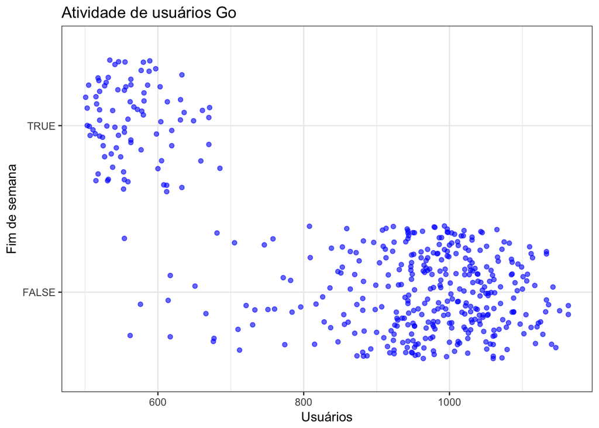

```r
dados.go %>%
  ggplot(aes(x= users ,y = isWeekend)) + geom_jitter(width = .1, colour = "blue",alpha=0.6)+
  labs(title = "Atividade de usuários Go", x = "Usuários", y = "Fim de semana")
```

Cada ponto é um dia em que houve atividade no GitHub para a linguagem Go. Esse dia pode ter sido no final de semana ou não. Vemos que há uma concentração de dias que não são finais de semana e em que houve um número alto de usuários que programaram em Go. Em contrapartida, há uma concentração de dias que são do final de semana e em que houve um número mais baixo de usuários. Isso nos sugere que Go é mais popular em dias de semana do que em finais de semana.

Como estamos trabalhando apenas com uma amostra, essa visualização não é suficiente para responder com confiança se Go é mais popular no final de semana ou não. Usaremos uma técnica de inferência chamada bootstrap para coletar informações da amostra e criar um panorama onde nossas conclusões tenham cerca de 95% de confiança.

Em linha gerais, a técnica bootstrap funciona da seguinte maneira:

- Reescreve um conjunto de dados do mesmo tamanho da amostra original n vezes.
- Calcula a estatísca para cada amostra gerada;
- Encontra o desvio padrão desta estatística;

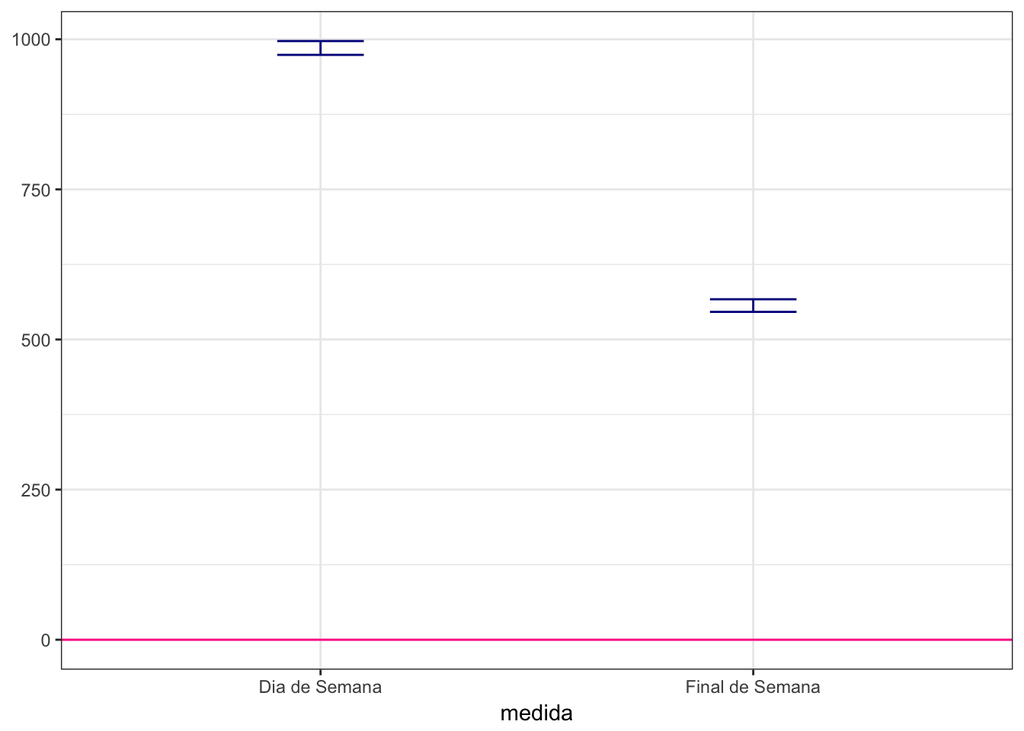

```r
# Mediana dos grupos separados

b1 = dados.go %>%
  filter(isWeekend == TRUE) %>%
  bootstrap(median(users))

median.go.fds = b1 %>%
  CI.percentile(probs = c(.025, .975))

b2 = dados.go %>%
  filter(isWeekend != TRUE) %>%
  bootstrap(median(users))

median.go.naofds = b2 %>%
  CI.percentile(probs = c(.025, .975))

df.medias = data.frame(rbind(median.go.fds, median.go.naofds))
df.medias$medida = c("Final de Semana", "Dia de Semana")

df.medias %>%
  ggplot(aes(x=medida, ymin = X2.5., ymax = X97.5.)) +
  geom_errorbar(width = .2, color=" darkblue") +
  geom_hline(yintercept = 0, colour = "deeppink")
```

Observamos que os intervalos de Dia de Semana e Final de Semana não se interceptam. Além disso podemos observar que em Dia de Semana atinge valores mais alto. Isso nos leva a concluir que Go é significatvivamente mais popular durante os dias da semana.

### Analisando com a linguagem Python.

Abaixo iremos observar como está linguagem se comporta em relação ao final de semana e dias de semana.

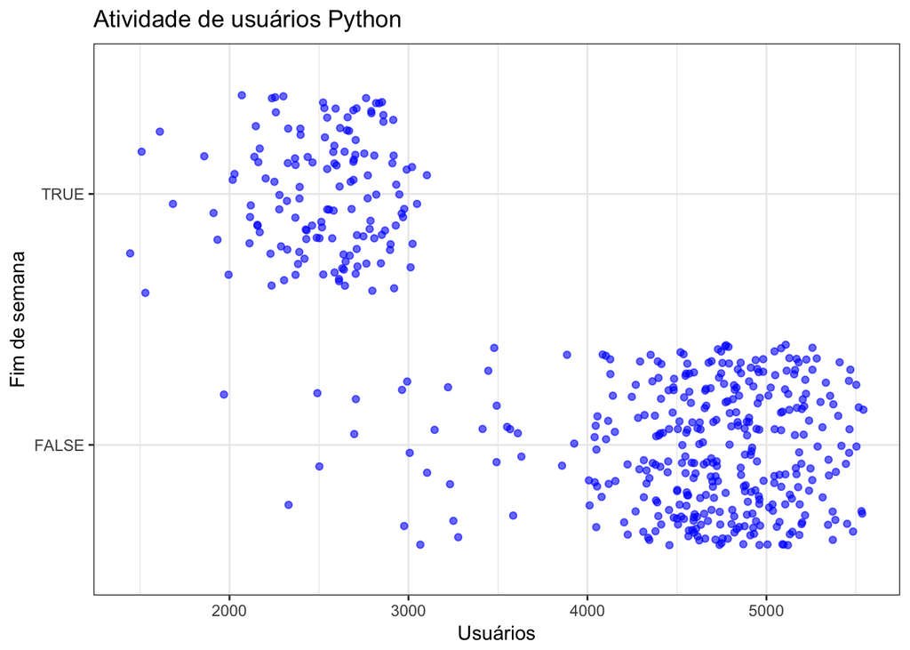

```r
dados.py %>%
  ggplot(aes(x= users ,y = isWeekend)) + geom_jitter(width = .1, colour = "blue",alpha=0.6)+
  labs(title = "Atividade de usuários Python", x = "Usuários", y = "Fim de semana")
```

Podemos observar o mesmo fenomeno que na linguagem Go em relação ao Final de Semana e Dia de Semana, porém notamos também que linguagem python possui mais usuarios que a linguagem Go. Como no processo estabelecido da linguagem Go iremos aplicar para Python e observar com mais confiaça tal fenomeno.

[figure not shown]

```r
# Mediana dos grupos separados

b1 = dados.py %>%
  filter(isWeekend == TRUE) %>%
  bootstrap(median(users))

median.py.fds = b1 %>%
  CI.percentile(probs = c(.025, .975))

b2 = dados.py %>%
  filter(isWeekend != TRUE) %>%
  bootstrap(median(users))

median.py.naofds = b2 %>%
  CI.percentile(probs = c(.025, .975))

df.medias = data.frame(rbind(median.go.fds, median.py.naofds))
df.medias$medida = c("Final de Semana", "Dia de Semana")

df.medias %>%
  ggplot(aes(x=medida, ymin = X2.5., ymax = X97.5.)) +
  geom_errorbar(width = .2, color=" darkblue") +
  geom_hline(yintercept = 0, colour = "deeppink")
```

## Comparandao duas linguagens, existe uma diferença significativa entre elas na sua variação de popularidade nos finais de semana?

Para está analise iremos comparar a popularidade, nos fins de semana, entre as duas lingaugens, para verificar qual delas tem maior variação.

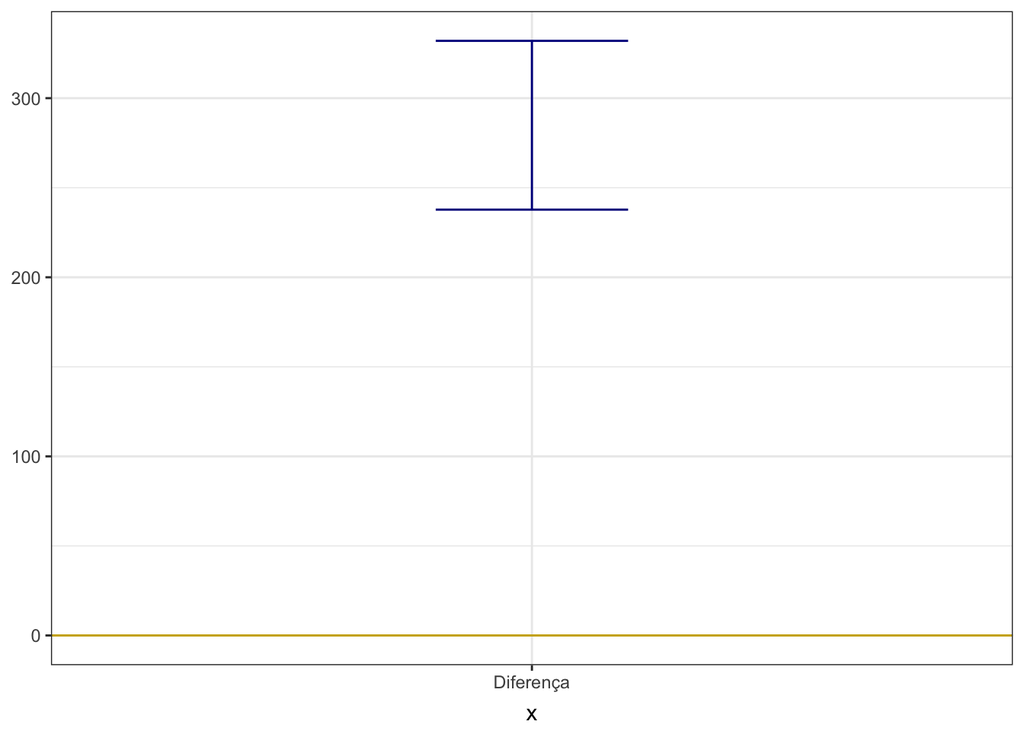

```r
mean.diff.ci = bootstrap2(data = (dados.py %>% filter(isWeekend == TRUE))$users,
                        data2 = (dados.go %>% filter(isWeekend  == TRUE))$users,
                        sd) %>%
  CI.percentile(probs = c(.025, .975))

data.frame(mean.diff.ci) %>%
  ggplot(aes(x = "Diferença", ymin = X2.5., ymax = X97.5.)) +
  geom_errorbar(width = .2, colour="darkblue") +
  geom_hline(yintercept = 0, colour="gold3")
```